# Seasonal births SIR POMP

Alexandra Souly

07/07/2020

## R Markdown

POMP stores all data in its own pomp class that can be used for complicated methods in the package, so I hope it will be easier to implement algorithms later within the package.

We start by specifying the deterministic model skeleton, I use the following equations:  
(“D” signifies the update value for the map in the equations)

```r
skel <- Csnippet("
  double b = b0*(1+b1*cos(2*M_PI*t/365));
  DS = S - Beta*S*I/N           + b*N - d*S ;
  DI = I + Beta*S*I/N - gamma*I       - d*I;
  DR = R              + gamma*I       - d*R;
")
```

Then I specify the stochastic stepping process:  
I used 1-exp(r) for the per capita stepping probabilities for rate r in the difference eqs and a binomial distribution for the numbers of individuals moving between compartments.

```r
stochStep <- Csnippet("
  double b = b0*(1+b1*cos(2*M_PI*t/365));
  p_SI = 1 - exp(-Beta*I/N);
  p_IR = 1 - exp(-gamma);
  p_b  = 1 - exp(-b);
  p_d  = 1 - exp(-d);

  n_SI = rbinom(S,p_SI);
  n_IR = rbinom(I,p_IR);

  b_N  = rbinom(N, p_b);
  d_I  = rbinom(I, p_d);
  d_R  = rbinom(R, p_d);
  d_S  = rbinom(S, p_d);

  S = S - n_SI        + b_N  - d_S;
  I = I + n_SI - n_IR        - d_I;
  R = R        + n_IR        - d_R;

")
```

I set some arbitrary initial states and parameters (5 infected out of, 13 days infectious period)

```r
# initial values of states
init1 <- Csnippet("
  S = N-5;
  I = 5;
  R = 0;
  ")

params1 <- c(Beta=1, b0=0.1, b1=0.4, gamma = 1/13, N= 763, d = 0.1)
```

Then we can create a POMP object:  
We follow the process for 700 days, POMP will use our stochastic process described above.

```r
closed_sir <- pomp(data=data.frame(time=1:700,data=NA),
                   times="time",
                   t0=0,
                   rprocess=discrete_time(step.fun=stochStep,delta.t=1),
                   skeleton = map(skel),
                   rinit=init1,
                   statenames=c("S","I","R", "p_SI", "p_IR", "p_b", "p_d", "n_SI", "n_IR", "b_N", "d_I", "d_S", "d_R"),
                   paramnames=c("Beta","b0","b1","gamma","N", "d"))
```

We then simulate 100 instances of the stochastic model and also calculate the trajectory with the deterministic model:

```r
sim <- simulate(closed_sir,params=params1,format = "data.frame", nsim = 100)
traj <- trajectory(closed_sir,params=params1,format="data.frame")
```

We first plot the population dynamics to see how the seasonal birth pulse looks like:

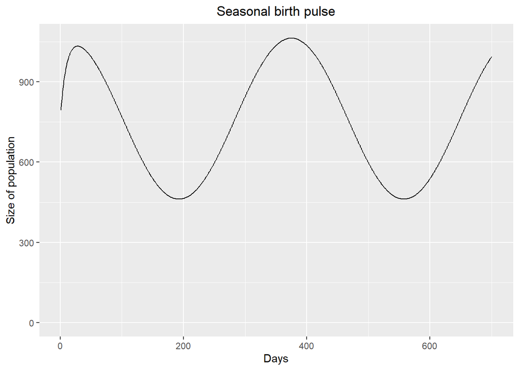

```r
birth_plot <- ggplot(NULL)+ geom_line(data=traj,aes(x=time, y = I+S+R,))+ylim(0,NA)+
              labs(title="Seasonal birth pulse")+xlab("Days")+ylab("Size of population")+
              theme(plot.title = element_text(hjust = 0.5))

plot(birth_plot)
```

We then plot to see how the stochastic results differ from the deterministic trajectory (in black). Red is infected, green is recovered and blue is supsceptible:

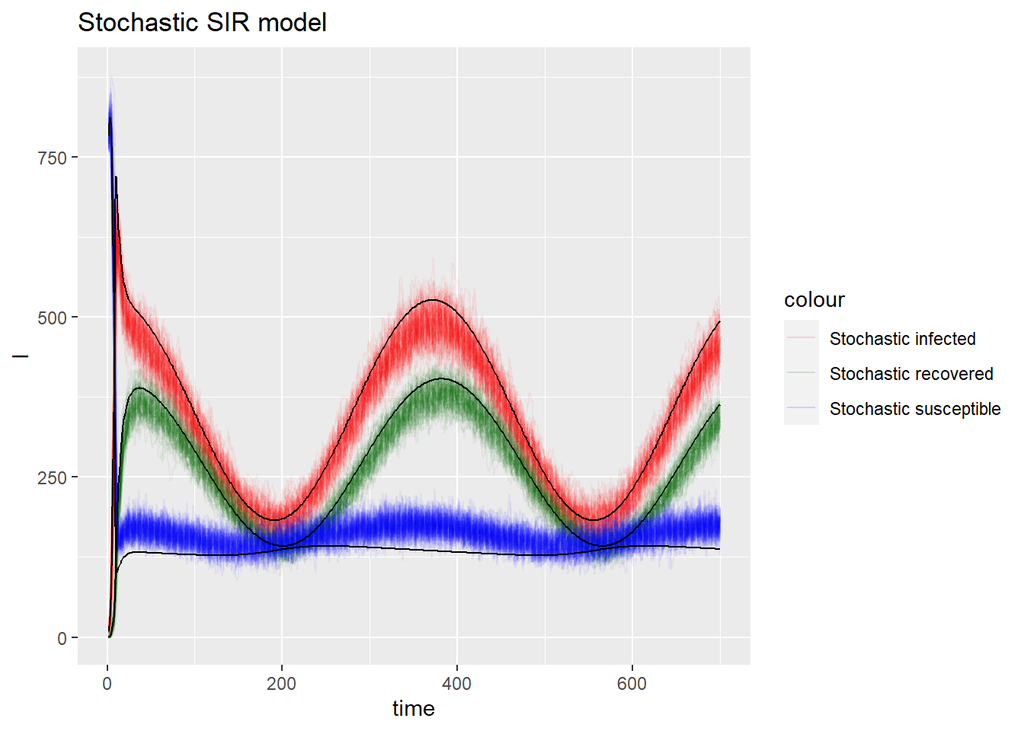